# What makes me tick?

Strava Heartrate Analysis

Julian During www.datannery.com  
2021-05-23

# Idea

In this post, I want to explore the heart rate data of my Strava Activities.

Heart rate can be considered as a measurement of the intensity of an physical activity. So in this post, I want to find out, what are the driving forces behind the intensity level of my activities. For future activities I would like to be able to determine, if the activity was less or more exhausting than comparable activities.

# Data

All my Strava activities are stored in a private Github repository. How this can be done, is described in an earlier post.

## Activities with Heartrate

Load all activities from the repository. Filter for those with heart rate data:

```r
act_raw <- function() {
  board_register_github(repo = "duju211/strava_act", branch = "master")

  df_act <- pin_get("df_act", board = "github")

  board_disconnect("github")

  df_act %>%
    filter(has_heartrate) %>%
    clean_names()
}
```

```r
df_act_raw <- act_raw()
```

The raw data consists of 261 activities. The aim of this post is to predict the `average_heartrate` with the available information.

```
# A tibble: 261 x 60
   resource_state name               distance moving_time elapsed_time
            <int> <chr>                 <dbl>       <int>        <int>
 1              2 "Saturday Breakfa~    9145.        3591         3801
 2              2 "Lauf am Nachmitt~    7194.        3022         3189
 3              2 "Sunny Forest Run"   11317         4559         4826
 4              2 "Bear Valley Clim~   61372.        9817        11848
 5              2 "Coffee Run"          3846.        1549         1549
 6              2 "Sunday Runday"       8394.        3651         3787
 7              2 "Hay Mountain Run~    9190.        3584         3853
 8              2 "Lauf am Nachmitt~    3755         1609         1629
 9              2 "April Weather Ru~   11075.        4568         4662
10              2 "Lauf am Nachmitt~    5928.        2542         2551
# ... with 251 more rows, and 55 more variables:
#   total_elevation_gain <dbl>, type <chr>, workout_type <int>,
#   id <chr>, external_id <chr>, upload_id <chr>, start_date <dttm>,
#   start_date_local <chr>, timezone <chr>, utc_offset <dbl>,
#   start_latlng <list>, end_latlng <list>, location_city <lgl>,
#   location_state <lgl>, location_country <chr>,
#   start_latitude <dbl>, start_longitude <dbl>,
#   achievement_count <int>, kudos_count <int>, comment_count <int>,
#   athlete_count <int>, photo_count <int>, trainer <lgl>,
#   commute <lgl>, manual <lgl>, private <lgl>, visibility <chr>,
#   flagged <lgl>, gear_id <chr>, from_accepted_tag <lgl>,
#   upload_id_str <chr>, average_speed <dbl>, max_speed <dbl>,
#   has_heartrate <lgl>, heartrate_opt_out <lgl>,
#   display_hide_heartrate_option <chr>, elev_high <dbl>,
#   elev_low <dbl>, pr_count <int>, total_photo_count <int>,
#   has_kudoed <lgl>, average_cadence <dbl>, average_heartrate <dbl>,
#   max_heartrate <dbl>, average_temp <int>, device_watts <lgl>,
#   average_watts <dbl>, weighted_average_watts <int>,
#   kilojoules <dbl>, max_watts <int>, athlete_id <chr>,
#   athlete_resource_state <int>, map_id <chr>,
#   map_summary_polyline <chr>, map_resource_state <int>
```

Preprocess data. Only select relevant columns and convert the `start_date` from a timestamp to a date column.

```r
pre_process_act <- function(df_act_raw) {
  df_act_raw %>%
    select(
      id, distance, moving_time, elapsed_time, total_elevation_gain, type,
      start_date, average_heartrate, elev_high, athlete_id,
      elev_low, max_speed, average_speed,
    ) %>%
    mutate(start_date = as_date(start_date)) %>%
    relocate(average_heartrate, id)
}
```

```r
df_act <- pre_process_act(df_act_raw)
```

```
# A tibble: 261 x 13
   average_heartrate id         distance moving_time elapsed_time
               <dbl> <chr>         <dbl>       <int>        <int>
 1              142. 5260343777    9145.        3591         3801
 2              141. 5242167588    7194.        3022         3189
 3              142. 5203404001   11317         4559         4826
 4              129. 5192561180   61372.        9817        11848
 5              134. 5158430271    3846.        1549         1549
 6              134. 5149047735    8394.        3651         3787
 7              146. 5120312418    9190.        3584         3853
 8              150. 5101547734    3755         1609         1629
 9              150. 5080465924   11075.        4568         4662
10              146. 5080464143    5928.        2542         2551
# ... with 251 more rows, and 8 more variables:
#   total_elevation_gain <dbl>, type <chr>, start_date <date>,
#   elev_high <dbl>, athlete_id <chr>, elev_low <dbl>,
#   max_speed <dbl>, average_speed <dbl>
```

## EDA Plots Activities

### Runs

```r
vis_eda_act_run <- function(df_act) {
  df_act %>%
    select(id, type, where(is.numeric)) %>%
    filter(type == "Run") %>%
    pivot_longer(
      cols = distance:last_col(), values_to = "value", names_to = "kpi"
    ) %>%
    ggplot(aes(x = value, y = average_heartrate)) +
    geom_point() +
    facet_wrap(~kpi, scales = "free")
}
```

```r
gg_eda_act_run <- vis_eda_act_run(df_act)
```

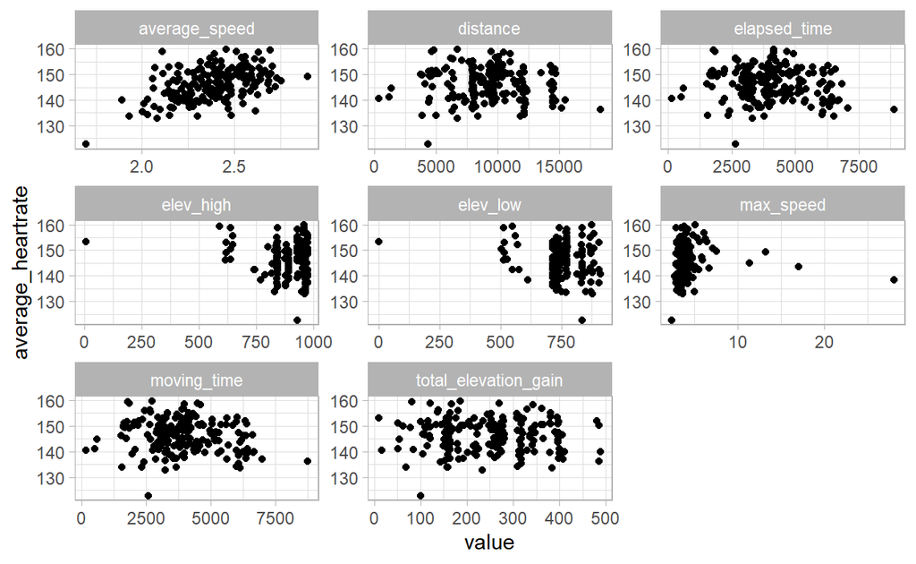

### Rides

```r
vis_eda_act_ride <- function(df_act) {
  df_act %>%
    select(id, type, where(is.numeric)) %>%
    filter(type == "Ride") %>%
    pivot_longer(
      cols = distance:last_col(), values_to = "value", names_to = "kpi"
    ) %>%
    ggplot(aes(x = value, y = average_heartrate)) +
    geom_point() +
    facet_wrap(~kpi, scales = "free")
}
```

```r
gg_eda_act_ride <- vis_eda_act_ride(df_act)
```

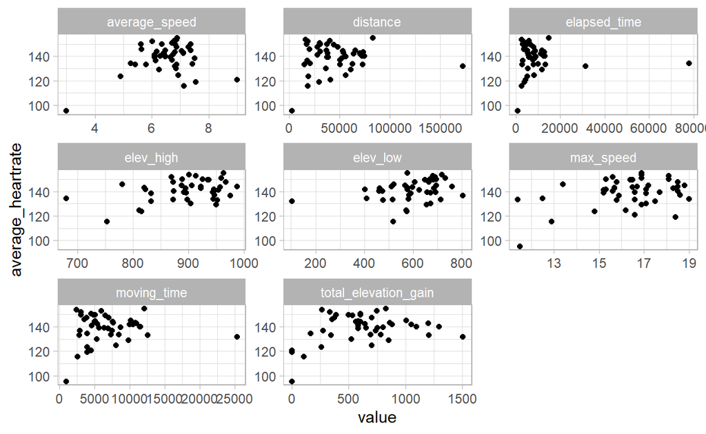

# Modeling

Set initial splits:

```r
set.seed(123)
init_split <- initial_split(df_act, strata = average_heartrate)
bpm_train <- training(init_split)
bpm_test <- testing(init_split)
set.seed(234)
bpm_folds <- bootstraps(bpm_train, strata = average_heartrate)
```

## GLMNet

Define the general specification of the model:

```r
glm_net_spec <- function() {
  glmnet_spec <-
    linear_reg(penalty = tune(), mixture = tune()) %>%
    set_mode("regression") %>%
    set_engine("glmnet")
}
```

```r
glm_net_specification <- glm_net_spec()
```

Define the preprocessing part of the model:

```r
glm_net_rec <- function(df_act) {
  glmnet_recipe <-
    recipe(formula = average_heartrate ~ ., data = df_act) %>%
    update_role(id, new_role = "ID") %>%
    step_date(start_date, features = c("year")) %>%
    step_rm(start_date) %>%
    step_string2factor(type, athlete_id) %>%
    step_knnimpute(elev_high, elev_low) %>%
    step_novel(all_nominal() & all_predictors(), -all_outcomes()) %>%
    step_dummy(all_nominal() & all_predictors(), -all_outcomes()) %>%
    step_zv(all_predictors()) %>%
    step_normalize(all_predictors() & all_numeric(), -all_nominal())
}
```

```r
glm_net_recipe <- glm_net_rec(df_act)
```

Define the workflow:

```r
glm_net_wf <- function(glm_net_recipe, glm_net_specification) {
  workflow() %>%
    add_recipe(glm_net_recipe) %>%
    add_model(glm_net_specification)
}
```

```r
glm_net_workflow <- glm_net_wf(glm_net_recipe, glm_net_specification)
```

```r
glm_net_workflow
```

```
== Workflow ==========================================================
Preprocessor: Recipe
Model: linear_reg()

-- Preprocessor ------------------------------------------------------
8 Recipe Steps

* step_date()
* step_rm()
* step_string2factor()
* step_impute_knn()
* step_novel()
* step_dummy()
* step_zv()
* step_normalize()

-- Model -------------------------------------------------------------
Linear Regression Model Specification (regression)

Main Arguments:
  penalty = tune()
  mixture = tune()

Computational engine: glmnet
```

Tune the workflow:

```r
glm_net_tune_wf <- function(glm_net_workflow, bpm_folds) {
  glmnet_grid <- tidyr::crossing(
    penalty = 10^seq(-6, -1, length.out = 20),
    mixture = c(0.05, 0.2, 0.4, 0.6, 0.8, 1))

  glmnet_tune <-
    tune_grid(glm_net_workflow, resamples = bpm_folds, grid = glmnet_grid)
}
```

```r
glm_net_tune <- glm_net_tune_wf(glm_net_workflow, bpm_folds)
```

```
# Tuning results
# Bootstrap sampling using stratification
# A tibble: 25 x 4
   splits           id          .metrics           .notes
   <list>           <chr>       <list>             <list>
 1 <split [195/71]> Bootstrap01 <tibble [240 x 6]> <tibble [0 x 1]>
 2 <split [195/67]> Bootstrap02 <tibble [240 x 6]> <tibble [0 x 1]>
 3 <split [195/75]> Bootstrap03 <tibble [240 x 6]> <tibble [0 x 1]>
 4 <split [195/76]> Bootstrap04 <tibble [240 x 6]> <tibble [0 x 1]>
 5 <split [195/78]> Bootstrap05 <tibble [240 x 6]> <tibble [0 x 1]>
 6 <split [195/73]> Bootstrap06 <tibble [240 x 6]> <tibble [0 x 1]>
 7 <split [195/66]> Bootstrap07 <tibble [240 x 6]> <tibble [0 x 1]>
 8 <split [195/63]> Bootstrap08 <tibble [240 x 6]> <tibble [0 x 1]>
 9 <split [195/74]> Bootstrap09 <tibble [240 x 6]> <tibble [0 x 1]>
10 <split [195/55]> Bootstrap10 <tibble [240 x 6]> <tibble [0 x 1]>
# ... with 15 more rows
```

Determine the best parameter set:

```r
show_best(glm_net_tune, metric = "rmse")
```

```
# A tibble: 5 x 8
  penalty mixture .metric .estimator  mean     n std_err .config
    <dbl>   <dbl> <chr>   <chr>      <dbl> <int>   <dbl> <chr>
1     0.1     1   rmse    standard    7.34    25   0.139 Preprocessor~
2     0.1     0.8 rmse    standard    7.36    25   0.155 Preprocessor~
3     0.1     0.6 rmse    standard    7.36    25   0.156 Preprocessor~
4     0.1     0.4 rmse    standard    7.37    25   0.156 Preprocessor~
5     0.1     0.2 rmse    standard    7.40    25   0.155 Preprocessor~
```

Fit the model one last time with the determined parameters:

```r
glm_net_last_fit <- function(glm_net_workflow, glm_net_tune, init_split) {
  final_glm <- glm_net_workflow %>%
    finalize_workflow(select_best(glm_net_tune, metric = "rmse"))

  last_fit(final_glm, init_split)
}
```

```r
glm_net_fit <- glm_net_last_fit(glm_net_workflow, glm_net_tune, init_split)
```

Evaluate the performance:

```r
collect_metrics(glm_net_fit)
```

```
# A tibble: 2 x 4
  .metric .estimator .estimate .config
  <chr>   <chr>          <dbl> <chr>
1 rmse    standard       8.11  Preprocessor1_Model1
2 rsq     standard       0.277 Preprocessor1_Model1
```

```r
vis_glm_net_pred <- function(glm_net_fit) {
  collect_predictions(glm_net_fit) %>%
    bind_cols(
      select(testing(first(pull(glm_net_fit, splits))), -average_heartrate)) %>%
    ggplot(aes(x = average_heartrate, y = .pred, color = type)) +
    geom_point() +
    geom_abline(linetype = 2) +
    coord_fixed()
}
```

```r
gg_glm_net_fit <- vis_glm_net_pred(glm_net_fit)
```

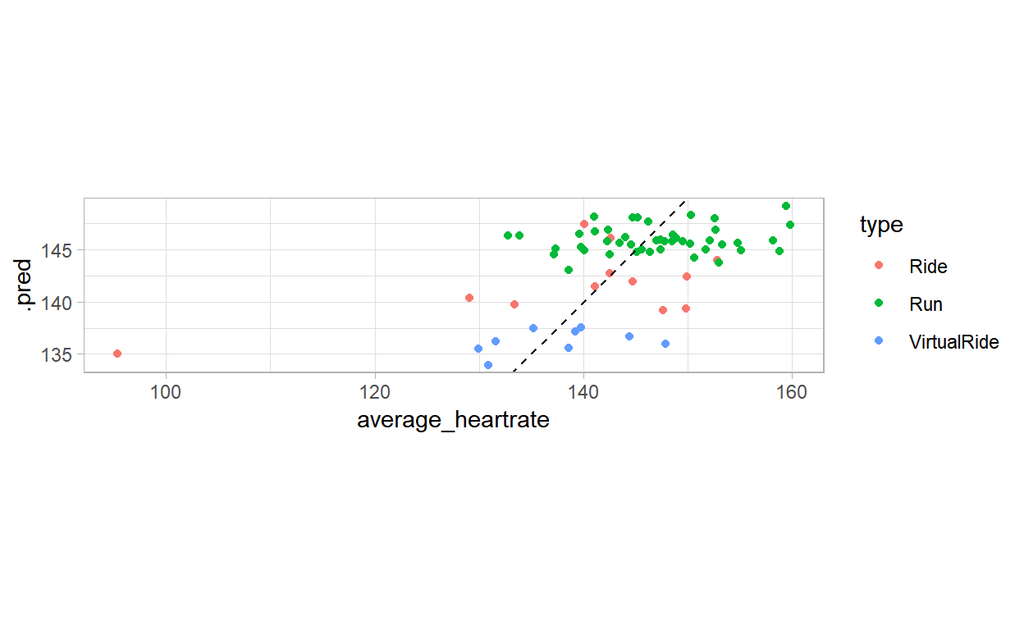

## Random Forest

Define the general specification of the model:

```r
rf_spec <- function() {
  rand_forest(mtry = tune(), min_n = tune(), trees = 1000) %>%
    set_mode("regression") %>%
    set_engine("ranger")
}
```

```r
rf_specification <- rf_spec()
```

Define model preprocessing steps:

```r
rf_rec <- function(df_act_run) {
  ranger_recipe <-
    recipe(formula = average_heartrate ~ ., data = select(df_act_run, -id)) %>%
    #add_role(id, new_role = "ID") %>%
    step_string2factor(type, athlete_id) %>%
    step_knnimpute(elev_high, elev_low)
}
```

```r
rf_recipe <- rf_rec(df_act)
```

Define the workflow:

```r
rf_wf <- function(rf_recipe, rf_specification) {
  workflow() %>%
    add_recipe(rf_recipe) %>%
    add_model(rf_specification)
}
```

```r
rf_workflow <- rf_wf(rf_recipe, rf_specification)
```

```r
rf_workflow
```

```
== Workflow ==========================================================
Preprocessor: Recipe
Model: rand_forest()

-- Preprocessor ------------------------------------------------------
2 Recipe Steps

* step_string2factor()
* step_impute_knn()

-- Model -------------------------------------------------------------
Random Forest Model Specification (regression)

Main Arguments:
  mtry = tune()
  trees = 1000
  min_n = tune()

Computational engine: ranger
```

Tune the workflow:

```r
rf_tune_wf <- function(ranger_workflow, bpm_folds) {
  set.seed(41210)
  tune_grid(ranger_workflow, resamples = bpm_folds, grid = 11)
}
```

```r
rf_tune <- rf_tune_wf(rf_workflow, bpm_folds)
```

```
# Tuning results
# Bootstrap sampling using stratification
# A tibble: 25 x 4
   splits           id          .metrics          .notes
   <list>           <chr>       <list>            <list>
 1 <split [195/71]> Bootstrap01 <tibble [22 x 6]> <tibble [0 x 1]>
 2 <split [195/67]> Bootstrap02 <tibble [22 x 6]> <tibble [0 x 1]>
 3 <split [195/75]> Bootstrap03 <tibble [22 x 6]> <tibble [0 x 1]>
 4 <split [195/76]> Bootstrap04 <tibble [22 x 6]> <tibble [0 x 1]>
 5 <split [195/78]> Bootstrap05 <tibble [22 x 6]> <tibble [0 x 1]>
 6 <split [195/73]> Bootstrap06 <tibble [22 x 6]> <tibble [0 x 1]>
 7 <split [195/66]> Bootstrap07 <tibble [22 x 6]> <tibble [0 x 1]>
 8 <split [195/63]> Bootstrap08 <tibble [22 x 6]> <tibble [0 x 1]>
 9 <split [195/74]> Bootstrap09 <tibble [22 x 6]> <tibble [0 x 1]>
10 <split [195/55]> Bootstrap10 <tibble [22 x 6]> <tibble [0 x 1]>
# ... with 15 more rows
```

Determine the best parameter set:

```r
show_best(rf_tune, metric = "rmse")
```

```
# A tibble: 5 x 8
   mtry min_n .metric .estimator  mean     n std_err .config
  <int> <int> <chr>   <chr>      <dbl> <int>   <dbl> <chr>
1     7    34 rmse    standard    7.15    25   0.156 Preprocessor1_Mo~
2     5    26 rmse    standard    7.15    25   0.153 Preprocessor1_Mo~
3     8    33 rmse    standard    7.16    25   0.157 Preprocessor1_Mo~
4     2    22 rmse    standard    7.16    25   0.143 Preprocessor1_Mo~
5     9    28 rmse    standard    7.17    25   0.154 Preprocessor1_Mo~
```

Fit the model one last time with the determined parameters:

```r
rf_last_fit <- function(rf_workflow, rf_tune, init_split) {
  rf_final_wf <- finalize_workflow(
    rf_workflow, select_best(rf_tune, metric = "rmse"))

  rf_final_fit <- last_fit(rf_final_wf, init_split)
}
```

```r
rf_fit <- rf_last_fit(rf_workflow, rf_tune, init_split)
```

Evaluate the performance:

```r
collect_metrics(rf_fit)
```

```
# A tibble: 2 x 4
  .metric .estimator .estimate .config
  <chr>   <chr>          <dbl> <chr>
1 rmse    standard       8.94  Preprocessor1_Model1
2 rsq     standard       0.126 Preprocessor1_Model1
```

```r
vis_glm_net_pred <- function(glm_net_fit) {
  collect_predictions(glm_net_fit) %>%
    bind_cols(
      select(testing(first(pull(glm_net_fit, splits))), -average_heartrate)) %>%
    ggplot(aes(x = average_heartrate, y = .pred, color = type)) +
    geom_point() +
    geom_abline(linetype = 2) +
    coord_fixed()
}
```

```r
gg_rf_fit <- vis_glm_net_pred(rf_fit)
```

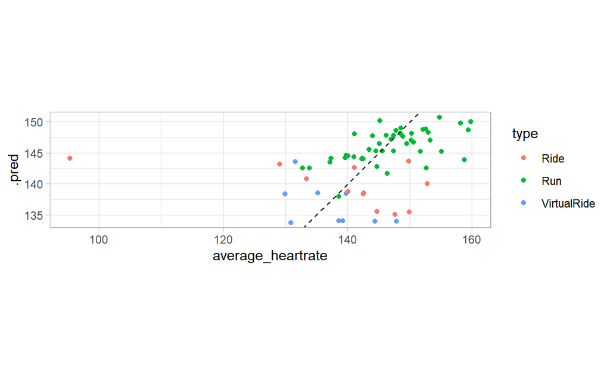

# Variable Importance

```r
vis_vip <- function(mod_spec, mod_tune, mod_rec, mod_method, bpm_train) {
  imp_spec <- mod_spec %>%
    finalize_model(select_best(mod_tune, metric = "rmse")) %>%
    set_engine(mod_method, importance = "permutation")

  workflow() %>%
    add_recipe(mod_rec) %>%
    add_model(imp_spec) %>%
    fit(bpm_train) %>%
    pull_workflow_fit() %>%
    vip(aesthetics = list(alpha = 0.8, fill = "midnightblue"))
}
```

## GLMNet

```r
gg_glm_net_vip <- vis_vip(
  glm_net_specification, glm_net_tune, glm_net_recipe, "glmnet", bpm_train)
```

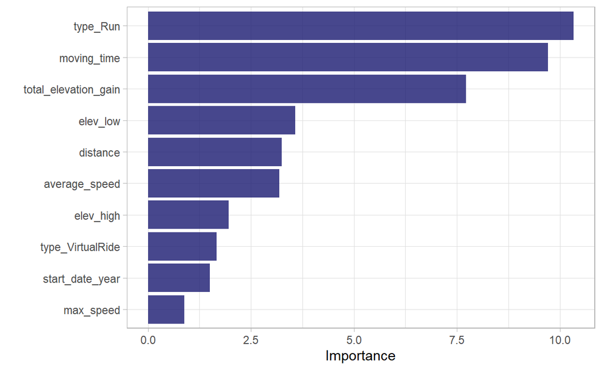

## Random Forest

```r
gg_rf_vip <- vis_vip(
  rf_specification, rf_tune, rf_recipe, "ranger", bpm_train)
```

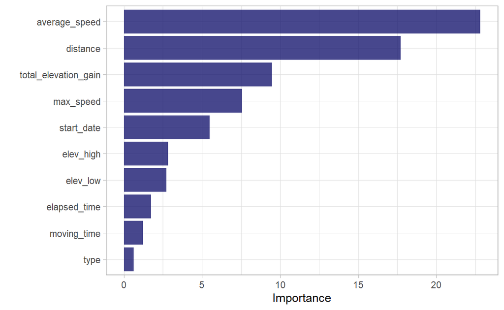

# Save Model

```r
board_register_github(repo = "duju211/strava_act", branch = "master")

pin(rf_fit$.workflow[[1]], "rf_mod", board = "github")

board_disconnect("github")
```